# Sales Forecasting using FB Prophet and SARIMAX models

### Importing the necessary packages

```python
import numpy as np
import pandas as pd
import matplotlib.pyplot as plt
import seaborn as sns
import time
import datetime as dt
import warnings
warnings.filterwarnings("ignore")
```

### The data

The data set contains all the transactions occurring between 01/12/2010 and 09/12/2011 for a UK-based and registered non-store online retail.The company mainly sells unique all-occasion gifts. Many customers of the company are wholesalers.

```python
# loading the dataset

df_ecommerce = pd.read_csv("data.csv", encoding= 'unicode_escape')
```

```python
# first 5 rows of the dataset

df_ecommerce.head()
```

|  | InvoiceNo | StockCode | Description | Quantity | InvoiceDate | UnitPrice | CustomerID | Country |
| --- | --- | --- | --- | --- | --- | --- | --- | --- |
| 0 | 536365 | 85123A | WHITE HANGING HEART T-LIGHT HOLDER | 6 | 12/1/2010 8:26 | 2.55 | 17850.0 | United Kingdom |
| 1 | 536365 | 71053 | WHITE METAL LANTERN | 6 | 12/1/2010 8:26 | 3.39 | 17850.0 | United Kingdom |
| 2 | 536365 | 84406B | CREAM CUPID HEARTS COAT HANGER | 8 | 12/1/2010 8:26 | 2.75 | 17850.0 | United Kingdom |
| 3 | 536365 | 84029G | KNITTED UNION FLAG HOT WATER BOTTLE | 6 | 12/1/2010 8:26 | 3.39 | 17850.0 | United Kingdom |
| 4 | 536365 | 84029E | RED WOOLLY HOTTIE WHITE HEART. | 6 | 12/1/2010 8:26 | 3.39 | 17850.0 | United Kingdom |

```python
# dimensions of the data

df_ecommerce.shape
```

```
(541909, 8)
```

There are 541909 rows and 8 coulmns in our data

```python
# information about the dataset

df_ecommerce.info()
```

```
<class 'pandas.core.frame.DataFrame'>
RangeIndex: 541909 entries, 0 to 541908
Data columns (total 8 columns):
 #   Column       Non-Null Count   Dtype
---  ------       --------------   -----
 0   InvoiceNo    541909 non-null  object
 1   StockCode    541909 non-null  object
 2   Description  540455 non-null  object
 3   Quantity     541909 non-null  int64
 4   InvoiceDate  541909 non-null  object
 5   UnitPrice    541909 non-null  float64
 6   CustomerID   406829 non-null  float64
 7   Country      541909 non-null  object
dtypes: float64(2), int64(1), object(5)
memory usage: 33.1+ MB
```

```python
# columns in the dataset

df_ecommerce.columns
```

```
Index(['InvoiceNo', 'StockCode', 'Description', 'Quantity', 'InvoiceDate',
       'UnitPrice', 'CustomerID', 'Country'],
      dtype='object')
```

### Data Pre-processing

Since the "Quantity" column signifies quantity of orders, it is safe to assume that the quantity can never be negative. We shall now look into different values of the "Quantity" column

```python
df_ecommerce[(df_ecommerce.Quantity <0)].count()['Quantity']
```

```
10624
```

```python
df_ecommerce['Quantity'].unique()
```

[output not shown]

[output cut: 36 more lines]

[output not shown]

We may notice above that the "Quantity" column 10624 rows that have values that are less than 0. We shall now drop these rows and retain only the records for which the "Quantity" is greater than 0.

```python
df_ecommerce = df_ecommerce[(df_ecommerce.Quantity >=0)]
df_ecommerce
```

|  | InvoiceNo | StockCode | Description | Quantity | InvoiceDate | UnitPrice | CustomerID | Country |
| --- | --- | --- | --- | --- | --- | --- | --- | --- |
| 0 | 536365 | 85123A | WHITE HANGING HEART T-LIGHT HOLDER | 6 | 12/1/2010 8:26 | 2.55 | 17850.0 | United Kingdom |
| 1 | 536365 | 71053 | WHITE METAL LANTERN | 6 | 12/1/2010 8:26 | 3.39 | 17850.0 | United Kingdom |
| 2 | 536365 | 84406B | CREAM CUPID HEARTS COAT HANGER | 8 | 12/1/2010 8:26 | 2.75 | 17850.0 | United Kingdom |
| 3 | 536365 | 84029G | KNITTED UNION FLAG HOT WATER BOTTLE | 6 | 12/1/2010 8:26 | 3.39 | 17850.0 | United Kingdom |
| 4 | 536365 | 84029E | RED WOOLLY HOTTIE WHITE HEART. | 6 | 12/1/2010 8:26 | 3.39 | 17850.0 | United Kingdom |
| ... | ... | ... | ... | ... | ... | ... | ... | ... |
| 541904 | 581587 | 22613 | PACK OF 20 SPACEBOY NAPKINS | 12 | 12/9/2011 12:50 | 0.85 | 12680.0 | France |
| 541905 | 581587 | 22899 | CHILDREN'S APRON DOLLY GIRL | 6 | 12/9/2011 12:50 | 2.10 | 12680.0 | France |
| 541906 | 581587 | 23254 | CHILDRENS CUTLERY DOLLY GIRL | 4 | 12/9/2011 12:50 | 4.15 | 12680.0 | France |
| 541907 | 581587 | 23255 | CHILDRENS CUTLERY CIRCUS PARADE | 4 | 12/9/2011 12:50 | 4.15 | 12680.0 | France |
| 541908 | 581587 | 22138 | BAKING SET 9 PIECE RETROSPOT | 3 | 12/9/2011 12:50 | 4.95 | 12680.0 | France |

531285 rows × 8 columns

```python
df_ecommerce[(df_ecommerce.UnitPrice < 0)]
```

|  | InvoiceNo | StockCode | Description | Quantity | InvoiceDate | UnitPrice | CustomerID | Country |
| --- | --- | --- | --- | --- | --- | --- | --- | --- |
| 299983 | A563186 | B | Adjust bad debt | 1 | 8/12/2011 14:51 | -11062.06 | NaN | United Kingdom |
| 299984 | A563187 | B | Adjust bad debt | 1 | 8/12/2011 14:52 | -11062.06 | NaN | United Kingdom |

Similarly we can notice that the "UnitPrice" column has values that are less than 0 for 2 records. Since, any price cannot be less than 0, we shall drop these records.

```python
df_ecommerce.drop(df_ecommerce[df_ecommerce['UnitPrice']<0].index, inplace=True)
```

```python
df_ecommerce.isnull().sum()
```

```
InvoiceNo           0
StockCode           0
Description       592
Quantity            0
InvoiceDate         0
UnitPrice           0
CustomerID     133359
Country             0
dtype: int64
```

We notice that the two columns "Description" and "CustomerID" have NULL values.

```python
df_ecommerce = df_ecommerce[df_ecommerce['CustomerID'].notna()]
df_ecommerce
```

|  | InvoiceNo | StockCode | Description | Quantity | InvoiceDate | UnitPrice | CustomerID | Country |
| --- | --- | --- | --- | --- | --- | --- | --- | --- |
| 0 | 536365 | 85123A | WHITE HANGING HEART T-LIGHT HOLDER | 6 | 12/1/2010 8:26 | 2.55 | 17850.0 | United Kingdom |
| 1 | 536365 | 71053 | WHITE METAL LANTERN | 6 | 12/1/2010 8:26 | 3.39 | 17850.0 | United Kingdom |
| 2 | 536365 | 84406B | CREAM CUPID HEARTS COAT HANGER | 8 | 12/1/2010 8:26 | 2.75 | 17850.0 | United Kingdom |
| 3 | 536365 | 84029G | KNITTED UNION FLAG HOT WATER BOTTLE | 6 | 12/1/2010 8:26 | 3.39 | 17850.0 | United Kingdom |
| 4 | 536365 | 84029E | RED WOOLLY HOTTIE WHITE HEART. | 6 | 12/1/2010 8:26 | 3.39 | 17850.0 | United Kingdom |
| ... | ... | ... | ... | ... | ... | ... | ... | ... |
| 541904 | 581587 | 22613 | PACK OF 20 SPACEBOY NAPKINS | 12 | 12/9/2011 12:50 | 0.85 | 12680.0 | France |
| 541905 | 581587 | 22899 | CHILDREN'S APRON DOLLY GIRL | 6 | 12/9/2011 12:50 | 2.10 | 12680.0 | France |
| 541906 | 581587 | 23254 | CHILDRENS CUTLERY DOLLY GIRL | 4 | 12/9/2011 12:50 | 4.15 | 12680.0 | France |
| 541907 | 581587 | 23255 | CHILDRENS CUTLERY CIRCUS PARADE | 4 | 12/9/2011 12:50 | 4.15 | 12680.0 | France |
| 541908 | 581587 | 22138 | BAKING SET 9 PIECE RETROSPOT | 3 | 12/9/2011 12:50 | 4.95 | 12680.0 | France |

397924 rows × 8 columns

```python
df_ecommerce.isnull().sum()
```

```
InvoiceNo      0
StockCode      0
Description    0
Quantity       0
InvoiceDate    0
UnitPrice      0
CustomerID     0
Country        0
dtype: int64
```

We notice that just by dropping the CustomerID column to retain only the not NULL values, the NULL values in the description column has also been taken care of.

```python
df_ecommerce.duplicated().sum()
```

```
5192
```

There are 5192 duplicate rows in the data set and now we shall remove them.

```python
# removing duplicates

df_ecommerce.drop_duplicates(inplace=True)
```

```python
df_ecommerce.head()
```

|  | InvoiceNo | StockCode | Description | Quantity | InvoiceDate | UnitPrice | CustomerID | Country |
| --- | --- | --- | --- | --- | --- | --- | --- | --- |
| 0 | 536365 | 85123A | WHITE HANGING HEART T-LIGHT HOLDER | 6 | 12/1/2010 8:26 | 2.55 | 17850.0 | United Kingdom |
| 1 | 536365 | 71053 | WHITE METAL LANTERN | 6 | 12/1/2010 8:26 | 3.39 | 17850.0 | United Kingdom |
| 2 | 536365 | 84406B | CREAM CUPID HEARTS COAT HANGER | 8 | 12/1/2010 8:26 | 2.75 | 17850.0 | United Kingdom |
| 3 | 536365 | 84029G | KNITTED UNION FLAG HOT WATER BOTTLE | 6 | 12/1/2010 8:26 | 3.39 | 17850.0 | United Kingdom |
| 4 | 536365 | 84029E | RED WOOLLY HOTTIE WHITE HEART. | 6 | 12/1/2010 8:26 | 3.39 | 17850.0 | United Kingdom |

```python
df_ecommerce.shape
```

```
(392732, 8)
```

After data-preprocessing, we have 392732 rows and 8 columnns in our dataset

### Feature Engineering

We have the columns for "Quantity" and "UnitPrice". Now we shall create a new column for Sales which is just the product of "Quantity" and "UnitPrice"

```python
df_ecommerce.insert(8,"Sales", df_ecommerce['Quantity']*df_ecommerce['UnitPrice'])
```

We notice that the InvoiceDate is of the 'object' datatype. We shall convert it into a datetime object so that it is easier to perform further manipulations

```python
# convert the "InvoiceDate" into a datetime object so that it is easier to perform further manipulations

df_ecommerce['InvoiceDate'] = df_ecommerce.InvoiceDate.astype('datetime64')
```

```python
df_ecommerce.info()
```

```
<class 'pandas.core.frame.DataFrame'>
Int64Index: 392732 entries, 0 to 541908
Data columns (total 9 columns):
 #   Column       Non-Null Count   Dtype
---  ------       --------------   -----
 0   InvoiceNo    392732 non-null  object
 1   StockCode    392732 non-null  object
 2   Description  392732 non-null  object
 3   Quantity     392732 non-null  int64
 4   InvoiceDate  392732 non-null  datetime64[ns]
 5   UnitPrice    392732 non-null  float64
 6   CustomerID   392732 non-null  float64
 7   Country      392732 non-null  object
 8   Sales        392732 non-null  float64
dtypes: datetime64[ns](1), float64(3), int64(1), object(4)
memory usage: 30.0+ MB
```

The InvoiceDate is now a datatime datatype. Now we shall create columns for date, year, month, week of the year, day of the week, hour of the day.

```python
# Creating a date column

df_ecommerce['Date'] = df_ecommerce['InvoiceDate'].dt.date
```

```python
# Creating a year column

df_ecommerce['Year'] = df_ecommerce['InvoiceDate'].dt.year
```

```python
# Creating a month column

df_ecommerce['Month'] = df_ecommerce['InvoiceDate'].dt.month
```

```python
# Creating a week of the year column

df_ecommerce['WeekOfYear'] = df_ecommerce['InvoiceDate'].dt.isocalendar().week
```

```python
# Creating a day of the week column

df_ecommerce['DayOfWeek'] = [d.day_name() for d in df_ecommerce['InvoiceDate']]
```

```python
# Ordering the day of the week column

df_ecommerce['DayOfWeek'] = pd.Categorical(df_ecommerce['DayOfWeek'],
                                 categories= ['Monday','Tuesday','Wednesday','Thursday','Friday','Saturday', 'Sunday'],
                                              ordered = True)
```

```python
# Creating the time of the day column

df_ecommerce['Time'] = [d.time() for d in df_ecommerce['InvoiceDate']]
```

```python
# Splitting the the time of the day column into different sessions in a day

df_ecommerce=df_ecommerce.assign(Session=pd.cut(df_ecommerce.InvoiceDate.dt.hour,
                            [0,6,12,18,23],
                            labels=['Night','Morning','Afternoon','Evening'],
                            include_lowest=True))
```

```python
# Creating the hour of the day column

df_ecommerce['Hour'] = df_ecommerce.InvoiceDate.dt.hour
```

```python
df_ecommerce.head()
```

|  | InvoiceNo | StockCode | Description | Quantity | InvoiceDate | UnitPrice | CustomerID | Country | Sales | Date | Year | Month | WeekOfYear | DayOfWeek | Time | Session | Hour |
| --- | --- | --- | --- | --- | --- | --- | --- | --- | --- | --- | --- | --- | --- | --- | --- | --- | --- |
| 0 | 536365 | 85123A | WHITE HANGING HEART T-LIGHT HOLDER | 6 | 2010-12-01 08:26:00 | 2.55 | 17850.0 | United Kingdom | 15.30 | 2010-12-01 | 2010 | 12 | 48 | Wednesday | 08:26:00 | Morning | 8 |
| 1 | 536365 | 71053 | WHITE METAL LANTERN | 6 | 2010-12-01 08:26:00 | 3.39 | 17850.0 | United Kingdom | 20.34 | 2010-12-01 | 2010 | 12 | 48 | Wednesday | 08:26:00 | Morning | 8 |
| 2 | 536365 | 84406B | CREAM CUPID HEARTS COAT HANGER | 8 | 2010-12-01 08:26:00 | 2.75 | 17850.0 | United Kingdom | 22.00 | 2010-12-01 | 2010 | 12 | 48 | Wednesday | 08:26:00 | Morning | 8 |
| 3 | 536365 | 84029G | KNITTED UNION FLAG HOT WATER BOTTLE | 6 | 2010-12-01 08:26:00 | 3.39 | 17850.0 | United Kingdom | 20.34 | 2010-12-01 | 2010 | 12 | 48 | Wednesday | 08:26:00 | Morning | 8 |
| 4 | 536365 | 84029E | RED WOOLLY HOTTIE WHITE HEART. | 6 | 2010-12-01 08:26:00 | 3.39 | 17850.0 | United Kingdom | 20.34 | 2010-12-01 | 2010 | 12 | 48 | Wednesday | 08:26:00 | Morning | 8 |

```python
df_ecommerce.isnull().sum()
```

```
InvoiceNo      0
StockCode      0
Description    0
Quantity       0
InvoiceDate    0
UnitPrice      0
CustomerID     0
Country        0
Sales          0
Date           0
Year           0
Month          0
WeekOfYear     0
DayOfWeek      0
Time           0
Session        0
Hour           0
dtype: int64
```

```python
df_ecommerce.columns
```

```
Index(['InvoiceNo', 'StockCode', 'Description', 'Quantity', 'InvoiceDate',
       'UnitPrice', 'CustomerID', 'Country', 'Sales', 'Date', 'Year', 'Month',
       'WeekOfYear', 'DayOfWeek', 'Time', 'Session', 'Hour'],
      dtype='object')
```

```python
df_ecommerce.shape
```

```
(392732, 17)
```

After the data manipulation and feature engineering, our data now has 392732 rows and 17 coulumns

```python
df_ecommerce.reset_index(inplace=True)
df_ecommerce.drop(axis=1, columns=['index'], inplace=True)
```

```python
df_ecommerce.head()
```

|  | InvoiceNo | StockCode | Description | Quantity | InvoiceDate | UnitPrice | CustomerID | Country | Sales | Date | Year | Month | WeekOfYear | DayOfWeek | Time | Session | Hour |
| --- | --- | --- | --- | --- | --- | --- | --- | --- | --- | --- | --- | --- | --- | --- | --- | --- | --- |
| 0 | 536365 | 85123A | WHITE HANGING HEART T-LIGHT HOLDER | 6 | 2010-12-01 08:26:00 | 2.55 | 17850.0 | United Kingdom | 15.30 | 2010-12-01 | 2010 | 12 | 48 | Wednesday | 08:26:00 | Morning | 8 |
| 1 | 536365 | 71053 | WHITE METAL LANTERN | 6 | 2010-12-01 08:26:00 | 3.39 | 17850.0 | United Kingdom | 20.34 | 2010-12-01 | 2010 | 12 | 48 | Wednesday | 08:26:00 | Morning | 8 |
| 2 | 536365 | 84406B | CREAM CUPID HEARTS COAT HANGER | 8 | 2010-12-01 08:26:00 | 2.75 | 17850.0 | United Kingdom | 22.00 | 2010-12-01 | 2010 | 12 | 48 | Wednesday | 08:26:00 | Morning | 8 |
| 3 | 536365 | 84029G | KNITTED UNION FLAG HOT WATER BOTTLE | 6 | 2010-12-01 08:26:00 | 3.39 | 17850.0 | United Kingdom | 20.34 | 2010-12-01 | 2010 | 12 | 48 | Wednesday | 08:26:00 | Morning | 8 |
| 4 | 536365 | 84029E | RED WOOLLY HOTTIE WHITE HEART. | 6 | 2010-12-01 08:26:00 | 3.39 | 17850.0 | United Kingdom | 20.34 | 2010-12-01 | 2010 | 12 | 48 | Wednesday | 08:26:00 | Morning | 8 |

```python
df_ecommerce.shape
```

```
(392732, 17)
```

After Feature Engineering, we have 392732 rows and 17 columnns in our dataset

### Exploratory Data Analysis (EDA)

### Count of transactions for each country

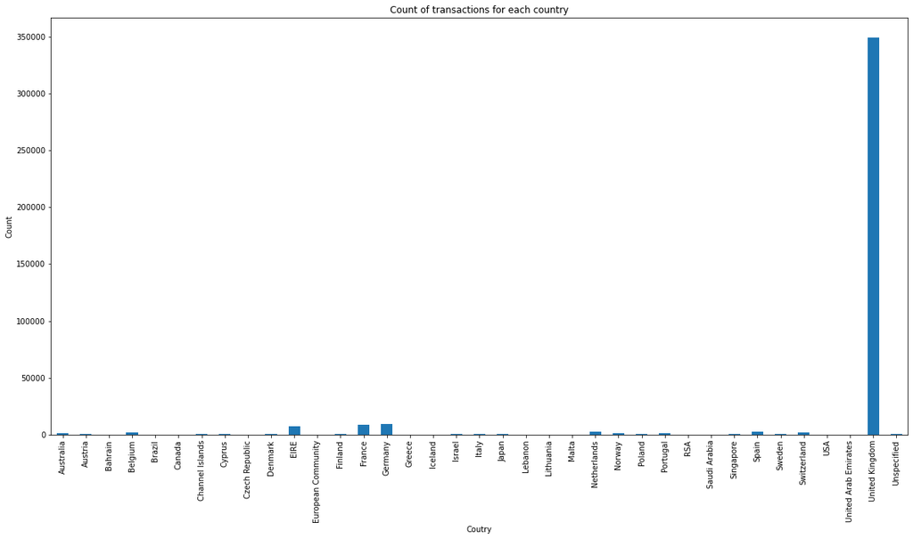

```python
# plotting the count of orders for each country

ax = df_ecommerce.groupby(['Country']).count()['InvoiceNo'].plot(kind = 'bar', figsize = (20,10),
                            title = 'Count of transactions for each country')
ax.set_xlabel('Coutry')
ax.set_ylabel('Count');
```

```python
df_ecommerce['Country'].value_counts()
```

```
United Kingdom          349227
Germany                   9027
France                    8327
EIRE                      7228
Spain                     2480
Netherlands               2363
Belgium                   2031
Switzerland               1842
Portugal                  1453
Australia                 1184
Norway                    1072
Italy                      758
Channel Islands            747
Finland                    685
Cyprus                     603
Sweden                     450
Austria                    398
Denmark                    380
Poland                     330
Japan                      321
Israel                     245
Unspecified                241
Singapore                  222
Iceland                    182
USA                        179
Canada                     151
Greece                     145
Malta                      112
United Arab Emirates        68
European Community          60
RSA                         58
Lebanon                     45
Lithuania                   35
Brazil                      32
Czech Republic              25
Bahrain                     17
Saudi Arabia                 9
Name: Country, dtype: int64
```

From the above chart, we can see that most of the cusomers (349227 which is almost 88% of the customers) are from United Kingdom.

And since the description of the dataset does mention that the data "is a transnational data set which contains all the transactions occurring between 01/12/2010 and 09/12/2011 for a UK-based and registered non-store online retail.The company mainly sells unique all-occasion gifts. Many customers of the company are wholesalers." So, it makes sense that most of the customers are from the UK.

### Count of transactions, quantity of orders, and sales on each day of the year

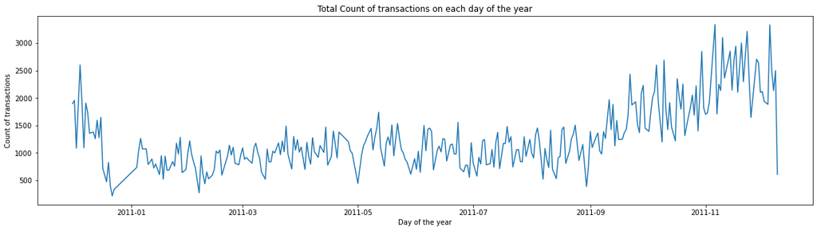

```python
# plotting the Count of orders on each day of the year

ax = df_ecommerce.groupby(['Date']).count()['InvoiceNo'].plot(kind = 'line', figsize = (20,5),
                            title = 'Total Count of transactions on each day of the year')
ax.set_xlabel('Day of the year')
ax.set_ylabel('Count of transactions');
```

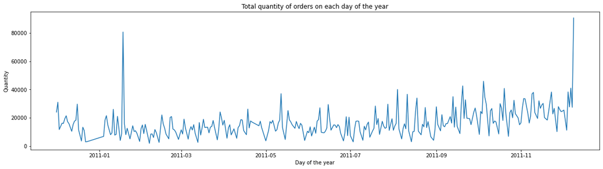

```python
# plotting the quantity of orders on each day of the year

ax = df_ecommerce.groupby(['Date']).sum()['Quantity'].plot(kind = 'line', figsize = (20,5),
                            title = 'Total quantity of orders on each day of the year')
ax.set_xlabel('Day of the year')
ax.set_ylabel('Quantity');
```

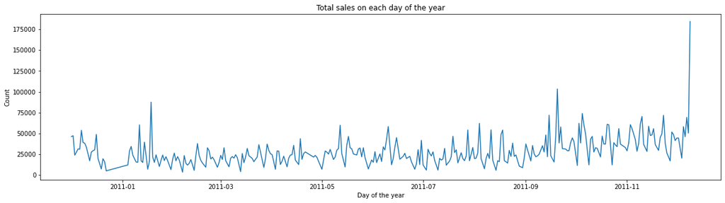

```python
# plotting the sales on each day of the year

ax = df_ecommerce.groupby(['Date']).sum()['Sales'].plot(kind = 'line', figsize = (20,5),
                            title = 'Total sales on each day of the year')
ax.set_xlabel('Day of the year')
ax.set_ylabel('Count');
```

### Insights

From the above time series chart, we can see that there is an increasing trend in the count of orders over the year.  
And there is also a seasonal trend in both the quantity of orders placed and the corresponding sales. However, we do notice that there are two peaks - one at the beginning of the year and one at the end. But we do not have enough evidence from the data to determine whether these are genuine data points or outliers. The description of the data says that "The company mainly sells unique all-occasion gifts. Many customers of the company are wholesalers." We can assume that some wholesale dealer bought bulk of the items on those particular days.

Similarly, we notice a peak at the end of the year, and since we do not know for sure whether it is an outlier, we shall have it in our analysis for now. If we know more about the data and the domain knowledge, we can make a more educated guess as to whether or not to include the datapoint in our analysis.

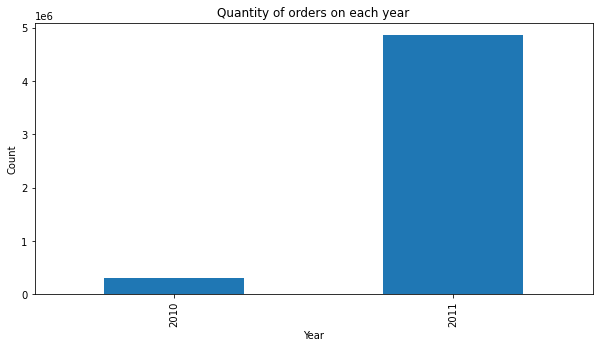

```python
# plotting the count of orders on each year

ax = df_ecommerce.groupby(['Year']).sum()['Quantity'].plot(kind = 'bar', figsize = (10,5),
                            title = 'Quantity of orders on each year')
ax.set_xlabel('Year')
ax.set_ylabel('Count');
```

### Quantity of orders and sales on each month of the year

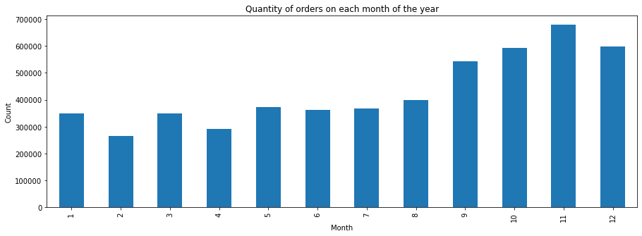

```python
# plotting the count of orders on each month of the year

ax = df_ecommerce.groupby(['Month']).sum()['Quantity'].plot(kind = 'bar', figsize = (15,5),
                            title = 'Quantity of orders on each month of the year')
ax.set_xlabel('Month')
ax.set_ylabel('Count');
```

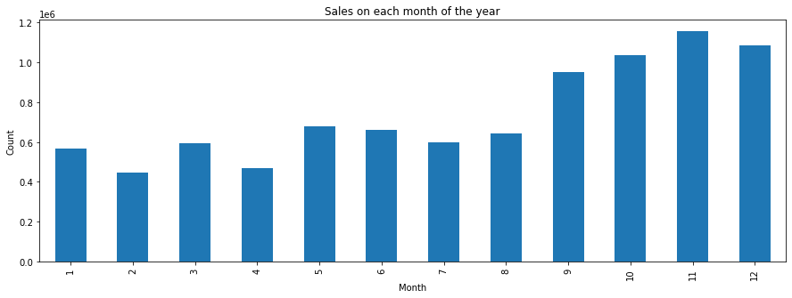

```python
# plotting the sales on each month of the year

ax = df_ecommerce.groupby(['Month']).sum()['Sales'].plot(kind = 'bar', figsize = (15,5),
                            title = 'Sales on each month of the year')
ax.set_xlabel('Month')
ax.set_ylabel('Count');
```

### Insights

Since the data is from 01/12/2010 and 09/12/2011, it seems logical that the number of orders are way more in 2011 as compared the number of orders in the year 2010. From the above two charts, we notice that the count of orders and the sales follow a similar pattern except for the months September and December where relatively less number of orders have produced comparitively more sales. We may infer that high priced good got sold more during these months as compared to other months.

### Sales on each week of the year

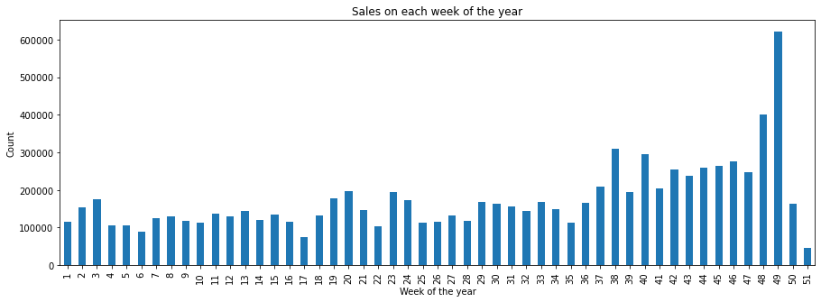

```python
# plotting the sales on each week of the year

ax = df_ecommerce.groupby(['WeekOfYear']).sum()['Sales'].plot(kind = 'bar', figsize = (15,5),
                            title = 'Sales on each week of the year')
ax.set_xlabel('Week of the year')
ax.set_ylabel('Count');
```

### Insights

We notice that the sales were at its peak during the 49th month of the year. However, as we noticed in the trend charts for the sales above, we found a peak in the last month which could have been on the 49th week.

### Sales on each day of the week

```
DayOfWeek
Monday       1363604.401
Tuesday      1697733.801
Wednesday    1584283.830
Thursday     1973015.730
Friday       1483080.811
Saturday           0.000
Sunday        785490.321
Name: Sales, dtype: float64
```

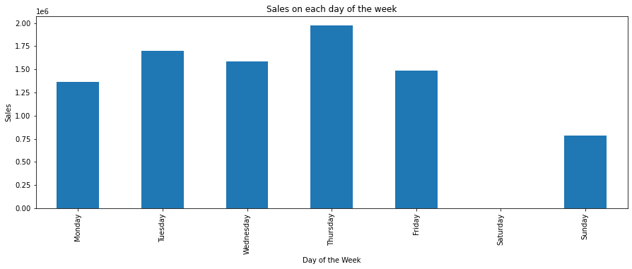

```python
# plotting the sales on each day of the week
print(df_ecommerce.groupby(['DayOfWeek']).sum()['Sales'])
ax = df_ecommerce.groupby(['DayOfWeek']).sum()['Sales'].plot(kind = 'bar', figsize = (15,5),
                            title = 'Sales on each day of the week')
ax.set_xlabel('Day of the Week')
ax.set_ylabel('Sales');
```

### Count of orders on each hour of the day

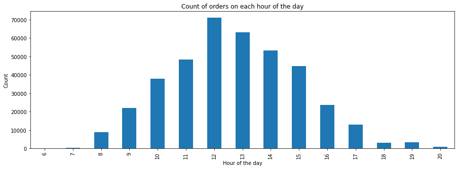

```python
# plotting the count of orders on each hour of the day

ax = df_ecommerce.groupby(['Hour']).count()['InvoiceNo'].plot(kind = 'bar', figsize = (15,5),
                            title = 'Count of orders on each hour of the day')
ax.set_xlabel('Hour of the day')
ax.set_ylabel('Count');
```

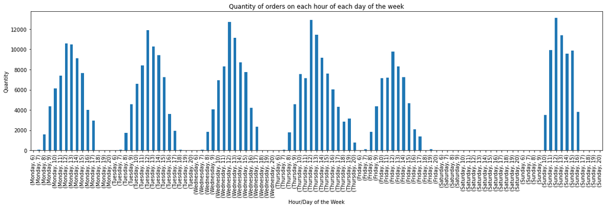

```python
# plotting the quantity of orders on each hour of each day of the week

ax = df_ecommerce.groupby(['DayOfWeek','Hour']).count()['Quantity'].plot(kind = 'bar', figsize = (20,5),
                            title = 'Quantity of orders on each hour of each day of the week')
ax.set_xlabel('Hour/Day of the Week')
ax.set_ylabel('Quantity');
```

### Insights

The sales seem to be peaking on Thursdays followed by high sales on Tuesday. Mondays, Wednesdays, and Fridays seem to having similar sales amounts. Sundays register the lowest sales. There are no sales on Saturday. So we may assume that the retail store does not function on Saturdays. And even with respect to everyday, the count of orders seem to peak around the afternoon and taper at the start and end of the day. We notice that the customer activity in at its highest with respect to placing orders during the day time from around 10 Am to 4 PM.

### Count of orders on each session of the day

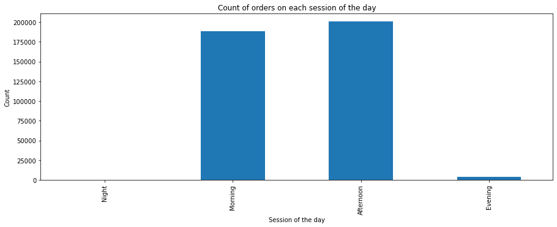

```python
# plotting the count of orders on each session of the day

ax = df_ecommerce.groupby(['Session']).count()['InvoiceNo'].plot(kind = 'bar', figsize = (15,5),
                            title = 'Count of orders on each session of the day')
ax.set_xlabel('Session of the day')
ax.set_ylabel('Count');
```

Most number of orders are placed during the mornings and afternoons.

### Top 20 orders based on the description

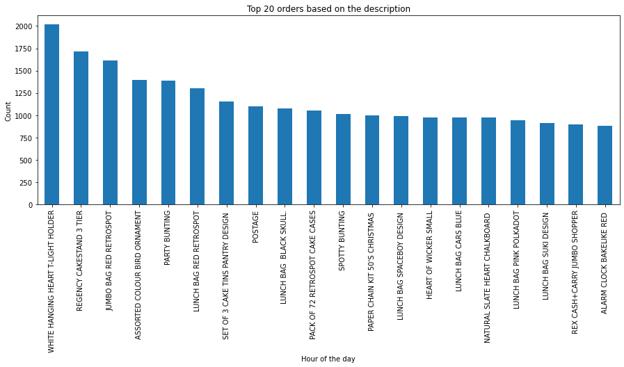

```python
# plotting the Top 20 orders based on the description

ax = df_ecommerce.groupby(['Description']).count()['InvoiceNo'].sort_values(ascending = False).head(20).plot(kind = 'bar',
                            figsize = (15,5),
                            title = 'Top 20 orders based on the description')
ax.set_xlabel('Hour of the day')
ax.set_ylabel('Count');
```

The item named "White Hanging Heart T-Light Holder" seems to be the highest sold item in the retail store.

## Sales forecasting using Fb Prophet time series modeling

FB Prophet is a procedure for forecasting time series data based on an Generalized Additive Model (GAM) where non-linear trends are fit with yearly, weekly, and daily seasonality, plus holiday effects.  
The systematic component of an additive model is the arithmetic sum of the individual effects of the predictors. Prophet combines seasonality, trend, and holidays.

y(t) = g(t) +s(t) +h(t) + et  
Where  
g(t) = trend component (the trend function which models non-periodic changes in the value of thetime series)  
s(t) = seasonal component (represents periodic changes (e.g., weekly and yearly seasonality))  
h(t) = holiday component (represents the effects of holidays)  
et = remainder component (represents any idiosyncratic changes or errors)

```python
from fbprophet import Prophet
```

```python
# import some modules that we need to initialize our environment

from fbprophet import Prophet
from fbprophet.diagnostics import cross_validation
from fbprophet.diagnostics import performance_metrics
from fbprophet.plot import plot_cross_validation_metric
```

```python
df_ecommerce.head()
```

|  | InvoiceNo | StockCode | Description | Quantity | InvoiceDate | UnitPrice | CustomerID | Country | Sales | Date | Year | Month | WeekOfYear | DayOfWeek | Time | Session | Hour |
| --- | --- | --- | --- | --- | --- | --- | --- | --- | --- | --- | --- | --- | --- | --- | --- | --- | --- |
| 0 | 536365 | 85123A | WHITE HANGING HEART T-LIGHT HOLDER | 6 | 2010-12-01 08:26:00 | 2.55 | 17850.0 | United Kingdom | 15.30 | 2010-12-01 | 2010 | 12 | 48 | Wednesday | 08:26:00 | Morning | 8 |
| 1 | 536365 | 71053 | WHITE METAL LANTERN | 6 | 2010-12-01 08:26:00 | 3.39 | 17850.0 | United Kingdom | 20.34 | 2010-12-01 | 2010 | 12 | 48 | Wednesday | 08:26:00 | Morning | 8 |
| 2 | 536365 | 84406B | CREAM CUPID HEARTS COAT HANGER | 8 | 2010-12-01 08:26:00 | 2.75 | 17850.0 | United Kingdom | 22.00 | 2010-12-01 | 2010 | 12 | 48 | Wednesday | 08:26:00 | Morning | 8 |
| 3 | 536365 | 84029G | KNITTED UNION FLAG HOT WATER BOTTLE | 6 | 2010-12-01 08:26:00 | 3.39 | 17850.0 | United Kingdom | 20.34 | 2010-12-01 | 2010 | 12 | 48 | Wednesday | 08:26:00 | Morning | 8 |
| 4 | 536365 | 84029E | RED WOOLLY HOTTIE WHITE HEART. | 6 | 2010-12-01 08:26:00 | 3.39 | 17850.0 | United Kingdom | 20.34 | 2010-12-01 | 2010 | 12 | 48 | Wednesday | 08:26:00 | Morning | 8 |

```python
ts = df_ecommerce[['Date','Sales']]
ts = ts.groupby(['Date'], as_index = False).agg(Sales = ('Sales', 'sum'))
ts
```

|  | Date | Sales |
| --- | --- | --- |
| 0 | 2010-12-01 | 46192.49 |
| 1 | 2010-12-02 | 47197.57 |
| 2 | 2010-12-03 | 23876.63 |
| 3 | 2010-12-05 | 31361.28 |
| 4 | 2010-12-06 | 31009.33 |
| ... | ... | ... |
| 300 | 2011-12-05 | 58081.09 |
| 301 | 2011-12-06 | 45989.66 |
| 302 | 2011-12-07 | 69230.60 |
| 303 | 2011-12-08 | 50395.96 |
| 304 | 2011-12-09 | 184329.66 |

305 rows × 2 columns

For running the Fb Prophet model, it is mandatory to have the ‘date’ column renamed as ‘ds’ and ‘sales’ column renamed as ‘y’.

```python
ts.columns = ['ds','y']
ts.columns
```

```
Index(['ds', 'y'], dtype='object')
```

```python
print("The mean value of sales is {}".format(ts['y'].mean()))
print("The std value of sales is {}".format(ts['y'].std()))
```

```
The mean value of sales is 29138.389816393497
The std value of sales is 17834.947343909098
```

The time series ranges from 2010-12-01 until 2011-12-09, it has 305 observations, a mean of 29138.38 and a standard deviation of 17834.94.

```python
ts.head()
```

|  | ds | y |
| --- | --- | --- |
| 0 | 2010-12-01 | 46192.49 |
| 1 | 2010-12-02 | 47197.57 |
| 2 | 2010-12-03 | 23876.63 |
| 3 | 2010-12-05 | 31361.28 |
| 4 | 2010-12-06 | 31009.33 |

```python
ts.tail()
```

|  | ds | y |
| --- | --- | --- |
| 300 | 2011-12-05 | 58081.09 |
| 301 | 2011-12-06 | 45989.66 |
| 302 | 2011-12-07 | 69230.60 |
| 303 | 2011-12-08 | 50395.96 |
| 304 | 2011-12-09 | 184329.66 |

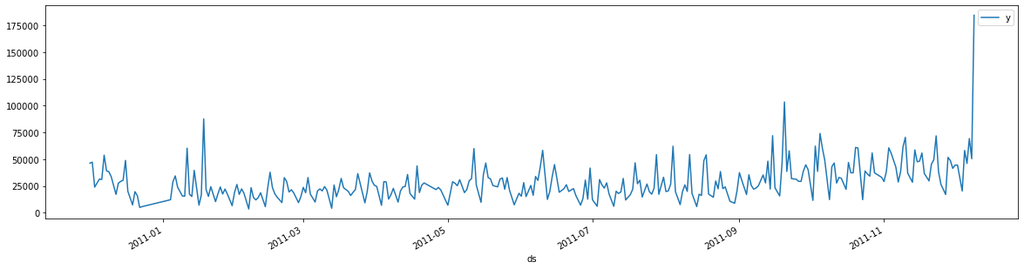

```python
ts['ds']=pd.to_datetime(ts.ds)
ts.plot(x='ds',y='y', figsize = (20,5));
```

We can notice that there is one huge spike on the last day of the dataset corrresponding to the date '2011-12-09' with the value 184329.66. Now let us see how the time series chart looks without that value.

```python
ts1 = ts.loc[:303,['ds','y']]
ts1
```

|  | ds | y |
| --- | --- | --- |
| 0 | 2010-12-01 | 46192.49 |
| 1 | 2010-12-02 | 47197.57 |
| 2 | 2010-12-03 | 23876.63 |
| 3 | 2010-12-05 | 31361.28 |
| 4 | 2010-12-06 | 31009.33 |
| ... | ... | ... |
| 299 | 2011-12-04 | 20232.00 |
| 300 | 2011-12-05 | 58081.09 |
| 301 | 2011-12-06 | 45989.66 |
| 302 | 2011-12-07 | 69230.60 |
| 303 | 2011-12-08 | 50395.96 |

304 rows × 2 columns

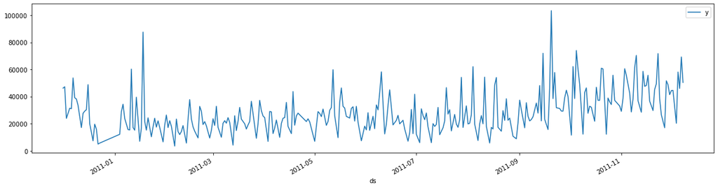

```python
ts1['ds']=pd.to_datetime(ts.ds)
ts1.plot(x='ds',y='y', figsize = (20,5));
```

#### Assumption

We notice that if we just remove that one data point the time series chart looks much better. Although, we do not know much abuot the description of the dataset, for now let us assume that this one point is an outlier and remove it from our data.

```python
ts = ts.loc[:303,['ds','y']]
ts
```

|  | ds | y |
| --- | --- | --- |
| 0 | 2010-12-01 | 46192.49 |
| 1 | 2010-12-02 | 47197.57 |
| 2 | 2010-12-03 | 23876.63 |
| 3 | 2010-12-05 | 31361.28 |
| 4 | 2010-12-06 | 31009.33 |
| ... | ... | ... |
| 299 | 2011-12-04 | 20232.00 |
| 300 | 2011-12-05 | 58081.09 |
| 301 | 2011-12-06 | 45989.66 |
| 302 | 2011-12-07 | 69230.60 |
| 303 | 2011-12-08 | 50395.96 |

304 rows × 2 columns

```python
print("The mean value of sales is {}".format(ts['y'].mean()))
print("The std value of sales is {}".format(ts['y'].std()))
```

```
The mean value of sales is 28627.892217105316
The std value of sales is 15472.15003619462
```

We can use statsmodels to perform a decomposition of this time series. The decomposition of time series is a statistical task that deconstructs a time series into several components, each representing one of the underlying categories of patterns. With statsmodels we will be able to see the trend, seasonal, and residual components of our data.

#### Decomposing the time series

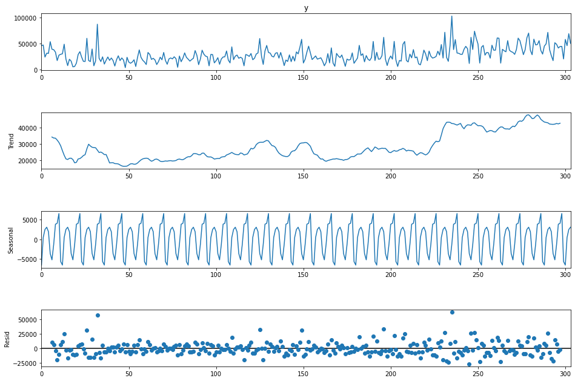

```python
from statsmodels.tsa.seasonal import seasonal_decompose
decompose  = seasonal_decompose(ts['y'],model='additive', period=12)
fig = plt.figure()
fig = decompose.plot()
fig.set_size_inches(15,10);
```

### Inference

#### Trend Component:

We find that the trend is increasing and there appears to be an overall upwards trend in the data.

#### Seasonal Component:

We can see that there is definite seasonality in the data, causing the sales to fluctuate in a periodic manner

#### Stationary and Seasonality Effect

Above we can see the data is somewhat nonstationary as there is an slightly increasing trend at the end and also it is definitely seasonal because of the constant fluctuations at time intervals. By stationarity, we mean that there should be constant mean, variance, and covariance in the data if we divide the data into segments with respect to time and seasonality means the same type of trend the data is following if segregated based on time intervals. Therefore, in general while working with a timeseries data like this, we need to make it stationary and nonseasonal. However, Fbprophet has the capability of handling this type of data especially the seasonal component and therefore we need not worry regarding the preprocessing part. The FbProphet library has the capability of handling stationarity within the data and also seasonality related components.

There are two types of seasonalities in any data.  
One is additive, which can be considered as the result of adding numbers. This type of data tends to show a linear trend.  
Another is multiplicative, which can be considered as the result of the compounding effect with percentage growth. This type of data tends to show an exponential trend.  
Since our data tends to show a linear trend, here we use FB Prophet model that fits additive seasonalities, meaning the effect of the seasonality is added to the trend to get the forecast is additive.

```python
len(ts)
```

```
304
```

#### Splitting train and test data

```python
train=ts[:244]
test=ts[244:]
```

```python
train.head()
```

[output not shown]

```python
test.head()
```

[output not shown]

### Building the FB Prophet model

```python
# a function to fit the FB Prophet model to the train and test data

def fit_prophet(dtf_train, dtf_test, lst_exog=None, model=None,
                freq="D", figsize=(15,10)):
    ## train
    model.fit(dtf_train)

    ## test
    dtf_prophet = model.make_future_dataframe(periods=len(dtf_test),
                  freq=freq, include_history=True)
    dtf_prophet = model.predict(dtf_prophet)
    fig1 = model.plot(dtf_prophet) # Plot the fit to past data and future forcast.
    fig2 = model.plot_components(dtf_prophet) # Plot breakdown of components.
    plt.show()
    dtf_train = dtf_train.merge(dtf_prophet[["ds","yhat"]],
                how="left").rename(columns={'yhat':'model',
                'y':'ts'}).set_index("ds")
    dtf_test = dtf_test.merge(dtf_prophet[["ds","yhat"]],
                how="left").rename(columns={'yhat':'forecast',
                'y':'ts'}).set_index("ds")

    ## evaluate
    dtf = dtf_train.append(dtf_test)
    dtf = utils_evaluate_forecast(dtf, figsize=figsize,
                                  title="Prophet")
    return dtf, model
```

```python
# function to evaluate the forecast

def utils_evaluate_forecast(dtf, title, plot=True, figsize=(20,13)):
    try:
        ## residuals
        dtf["residuals"] = dtf["ts"] - dtf["model"]
        dtf["error"] = dtf["ts"] - dtf["forecast"]
        dtf["error_pct"] = dtf["error"] / dtf["ts"]

        ## kpi
        residuals_mean = dtf["residuals"].mean()
        residuals_std = dtf["residuals"].std()
        error_mean = dtf["error"].mean()
        error_std = dtf["error"].std()
        mae = dtf["error"].apply(lambda x: np.abs(x)).mean()
        mape = dtf["error_pct"].apply(lambda x: np.abs(x)).mean()
        mse = dtf["error"].apply(lambda x: x**2).mean()
        rmse = np.sqrt(mse)  #root mean squared error

        ## intervals
        dtf["conf_int_low"] = dtf["forecast"] - 1.96*residuals_std
        dtf["conf_int_up"] = dtf["forecast"] + 1.96*residuals_std
        dtf["pred_int_low"] = dtf["forecast"] - 1.96*error_std
        dtf["pred_int_up"] = dtf["forecast"] + 1.96*error_std

        ## plot
        if plot==True:
            fig = plt.figure(figsize=figsize)
            fig.suptitle(title, fontsize=20)
            ax1 = fig.add_subplot(2,2, 1)
            ax2 = fig.add_subplot(2,2, 2, sharey=ax1)
            ax3 = fig.add_subplot(2,2, 3)
            ax4 = fig.add_subplot(2,2, 4)
            ### training
            dtf[pd.notnull(dtf["model"])][["ts","model"]].plot(color=["black","green"], title="Model", grid=True, ax=ax1)
            ax1.set(xlabel=None)
            ### test
            dtf[pd.isnull(dtf["model"])][["ts","forecast"]].plot(color=["black","red"], title="Forecast", grid=True, ax=ax2)
            ax2.fill_between(x=dtf.index, y1=dtf['pred_int_low'], y2=dtf['pred_int_up'], color='b', alpha=0.2)
            ax2.fill_between(x=dtf.index, y1=dtf['conf_int_low'], y2=dtf['conf_int_up'], color='b', alpha=0.3)
            ax2.set(xlabel=None)
            ### residuals
            dtf[["residuals","error"]].plot(ax=ax3, color=["green","red"], title="Residuals", grid=True)
            ax3.set(xlabel=None)
            ### residuals distribution
            dtf[["residuals","error"]].plot(ax=ax4, color=["green","red"], kind='kde', title="Residuals Distribution", grid=True)
            ax4.set(ylabel=None)
            plt.show()
            print("Training --> Residuals mean:", np.round(residuals_mean), " | std:", np.round(residuals_std))
            print("Test --> Error mean:", np.round(error_mean), " | std:", np.round(error_std),
                  " | mae:",np.round(mae), " | mape:",np.round(mape*100), "%  | mse:",np.round(mse), " | rmse:",np.round(rmse))

        return dtf[["ts","model","residuals","conf_int_low","conf_int_up",
                    "forecast","error","pred_int_low","pred_int_up"]]

    except Exception as e:
        print("--- got error ---")
        print(e)
```

## Base Model

```python
model = Prophet(growth="linear",
                seasonality_mode="additive",
                yearly_seasonality=True,
                weekly_seasonality=True,
                daily_seasonality=True);
```

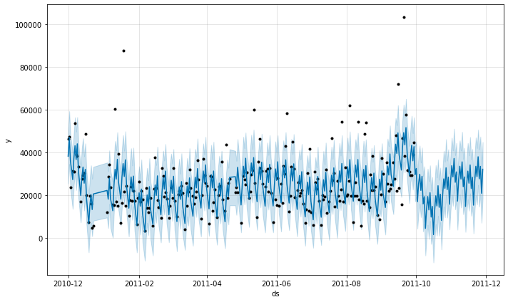

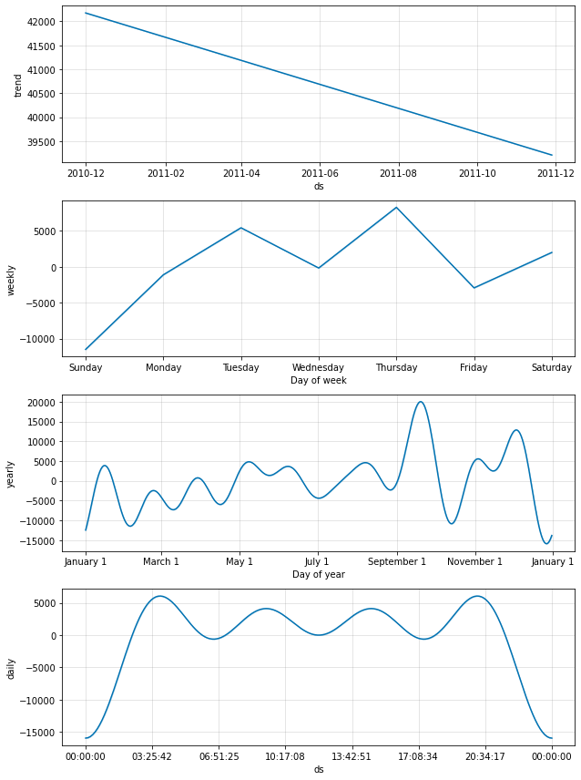

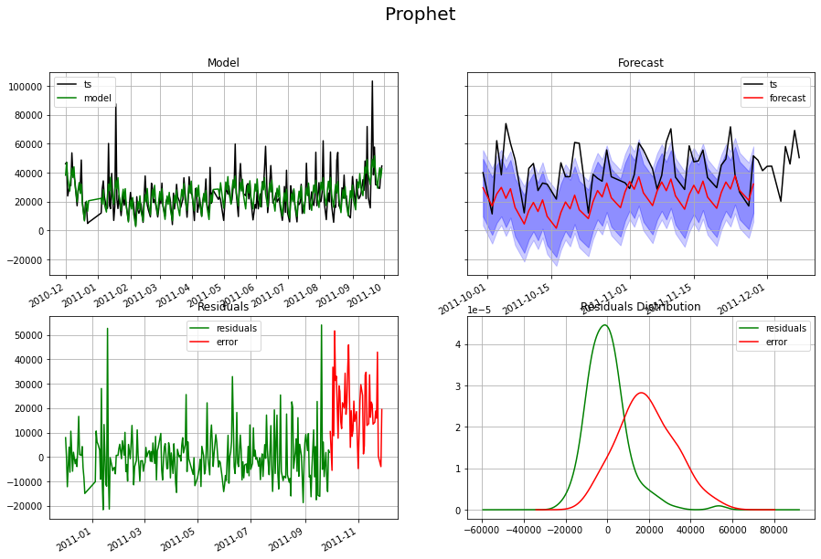

```
Training --> Residuals mean: -1.0  | std: 10186.0
Test --> Error mean: 18793.0  | std: 13278.0  | mae: 19395.0  | mape: 44.0 %  | mse: 526025768.0  | rmse: 22935.0
```

```python
dtf, model = fit_prophet(train, test, model=model, freq="D")
```

In the first plot above, the black dots represent actual measurements blue line displays Prophet’s forecast light blue window indicates uncertainty intervals. We also notice that the yearly seasonality is being overfitted with a lot of fluctuation points.

### Evaluation metrics

**Mean Absolute Error (MAE)** : The Mean Absolute Error is the average of the absolute difference between the actual and predicted values  
**Mean Absolute Percentage Error (MAPE)** : The Mean Absolute Percentge Error is the average of absolute percentage errors  
**Mean Squared Error (MSE)** : Mean Squared Error represents the average of the squared difference between the original and predicted values  
**Root Mean Squared Error (RMSE)** : Root Mean Squared Error is the square root of Mean Squared error. It measures the standard deviation of residuals

We shall use MAPE to evaluate our model. The MAPE for our base model is 44%. This indicates that over all the points predicted, we are out with an average of 44% from the true value.

## Hyperparameter optimization

**growth:** This parameter can be set to either "linear" or "logistic". By looking at the trend line, we notice a trend that keeps on growing with no real saturation insight. Hence, we shall set this parameter to "linear". If we plot the trend and notice a curve that is showing promise of saturation, then we would set this parameter to “logistic”

**seasonality_mode:** This parameter can be set to either "additive" or "multiplicative". This parameter indicates how your seasonality components should be integrated with the predictions. The default value here is additive with multiplicative being the other option. We use "additive" since our seasonality is almost “constant” over the entire period. Prophet default value for this is parameter is "additive"

**n_changepoints:** Changepoints are the points in your data where there are sudden and abrupt changes in the trend. This parameter determines how many change points we would like to have.

**changepoint_prior_scale:** The changepoint_prior_scale indicates how flexible the changepoints are allowed to be. As in, how much can the changepoints fit to the data. Large values will allow many changepoints and small values will allow fewer change points. I found 0.095 to result in the least MAPE.

**holidays_prior_scale:** This parameter determines how much of an effect holidays should have on your predictions. The default value is 10. However, when I increased the value to 20, it resulted in a lower MAPE. This makes sense because the data we are dealing with is a retail data and holidays might have a noticeable effect on the sales.

**add_country_holidays:** FB Prophet gives us an option to include the country holidays. Since we are dealing with the UK-based and registered non-store online retail store, I chose to include the UK holidays

I incorporated the hyperparameters in the model below.

```python
model = Prophet(growth="linear",
                seasonality_mode="additive",
                n_changepoints=25,
                changepoint_prior_scale = 0.095,
                holidays_prior_scale=20,
                yearly_seasonality=False,
                weekly_seasonality=False,
                daily_seasonality=False).add_seasonality(
                name='monthly',
                period=30.5,
                fourier_order=10,
                prior_scale=50).add_seasonality(
                name='daily',
                period=1,
                fourier_order=5,
                prior_scale=25).add_seasonality(
                name='weekly',
                period=7,
                fourier_order=20,
                prior_scale=25).add_seasonality(
                name='yearly',
                period=365.5,
                fourier_order=1,
                prior_scale=0.00001)
model.add_country_holidays(country_name='UK');
```

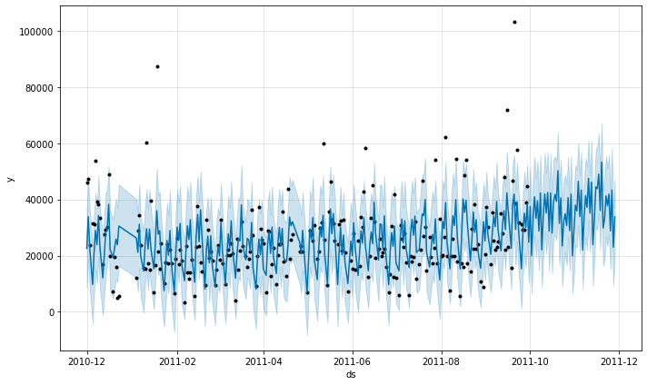

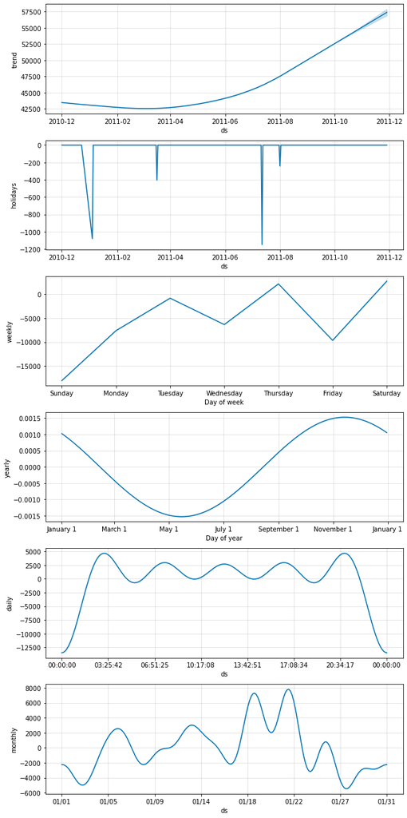

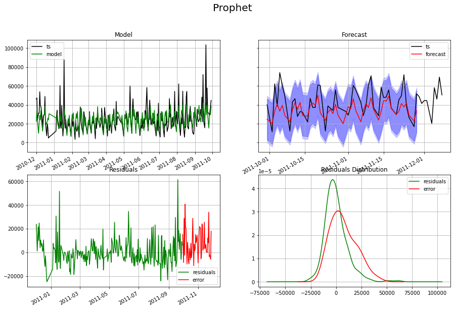

```
Training --> Residuals mean: 14.0  | std: 11055.0
Test --> Error mean: 7347.0  | std: 12506.0  | mae: 10953.0  | mape: 26.0 %  | mse: 207326231.0  | rmse: 14399.0
```

```python
dtf, model = fit_prophet(train, test, model=model, freq="D")
```

### The changepoint effect

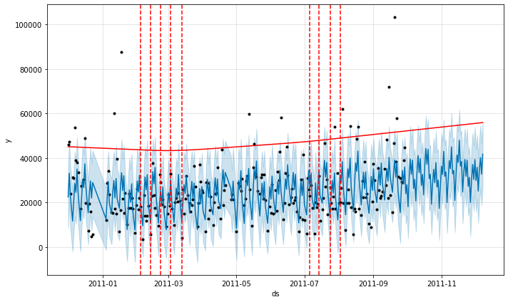

```python
fig=model.plot(forecast)
a=add_changepoints_to_plot(fig.gca(),model,forecast)
```

```python
model.changepoints
```

```
8     2010-12-10
16    2010-12-20
23    2011-01-07
31    2011-01-17
39    2011-01-26
47    2011-02-04
54    2011-02-13
62    2011-02-22
70    2011-03-03
78    2011-03-13
85    2011-03-21
93    2011-03-30
101   2011-04-08
109   2011-04-18
116   2011-05-01
124   2011-05-11
132   2011-05-20
140   2011-05-31
147   2011-06-08
155   2011-06-17
163   2011-06-27
171   2011-07-06
178   2011-07-14
186   2011-07-24
194   2011-08-02
Name: ds, dtype: datetime64[ns]
```

### Recommendation

In the above chart, the change points (red dotted lined) denote the points where the trend changes (either increases or decreases). Based on the dates (shown above) on which the trend changes, we can expect an increase or a decrease in sales in the future years around the same dates. This would help us in running appropriate marketing campaigns and planning for the inventory and logistics activities. With the help of some domain knoweldge expert we could fine tune the change points to reflect the specific marketing strategy roll-outs and promotion deals.

### The Holiday Effect

```python
model.train_holiday_names
```

```
0                                        New Year's Day
1                           New Year Holiday [Scotland]
2                New Year Holiday [Scotland] (Observed)
3                  St. Patrick's Day [Northern Ireland]
4                Battle of the Boyne [Northern Ireland]
5                        Summer Bank Holiday [Scotland]
6                           St. Andrew's Day [Scotland]
7                                         Christmas Day
8                              Christmas Day (Observed)
9                                           Good Friday
10       Easter Monday [England/Wales/Northern Ireland]
11                                              May Day
12                                  Spring Bank Holiday
13    Late Summer Bank Holiday [England/Wales/Northe...
14                                           Boxing Day
15                                Boxing Day (Observed)
16                            New Year's Day (Observed)
17                     Wedding of William and Catherine
dtype: object
```

### Recommendation

The above holidays which are specific to the United Kingdom holidays that were added to the model. However, with the help of domain knowledge experts, if the company wants to include other holidays such as "Thanksgiving", "Superbowl", etc we can provide them along with the other holidays to improve our forecast.

## ARIMA Implementation

```python
import pmdarima
import statsmodels.tsa.api as smt
```

```python
# the data needs only the 'Date' and the 'Sales' columns

ts = df_ecommerce[['Date','Sales']]
ts = ts.groupby(['Date'], as_index = False).agg(Sales = ('Sales', 'sum'))
ts
```

|  | Date | Sales |
| --- | --- | --- |
| 0 | 2010-12-01 | 46192.49 |
| 1 | 2010-12-02 | 47197.57 |
| 2 | 2010-12-03 | 23876.63 |
| 3 | 2010-12-05 | 31361.28 |
| 4 | 2010-12-06 | 31009.33 |
| ... | ... | ... |
| 300 | 2011-12-05 | 58081.09 |
| 301 | 2011-12-06 | 45989.66 |
| 302 | 2011-12-07 | 69230.60 |
| 303 | 2011-12-08 | 50395.96 |
| 304 | 2011-12-09 | 184329.66 |

305 rows × 2 columns

```python
# finding the optimal parameters for the ARIMA model

best_model = pmdarima.auto_arima(ts['Sales'],
                                 seasonal=True,stationary=False,
                                 m=7, information_criterion='aic',
                                 max_p=10, max_d=3, max_q=10,
                                 max_P=10, max_D=3, max_Q=10,
                                 error_action='ignore')
print("best model --> (p, d, q):", best_model.order, " and  (P, D, Q, s):", best_model.seasonal_order)
```

```
best model --> (p, d, q): (0, 1, 2)  and  (P, D, Q, s): (0, 0, 2, 7)
```

```python
# function to fit the SARIMAX model

def fit_sarimax(ts_train, ts_test, order=(1,0,1),
                seasonal_order=(0,0,0,0), exog_train=None,
                exog_test=None, figsize=(15,10)):
    ## train
    model = smt.SARIMAX(ts_train, order=order,
                        seasonal_order=seasonal_order,
                        exog=exog_train, enforce_stationarity=False,
                        enforce_invertibility=False).fit()
    dtf_train = ts_train.to_frame(name="ts")
    dtf_train["model"] = model.fittedvalues

    ## test
    dtf_test = ts_test.to_frame(name="ts")
    dtf_test["forecast"] = model.predict(start=len(ts_train),
                            end=len(ts_train)+len(ts_test)-1,
                            exog=exog_test)

    ## evaluate
    dtf = dtf_train.append(dtf_test)
    dtf = utils_evaluate_forecast(dtf, figsize=figsize, title=None)
    return dtf, model
```

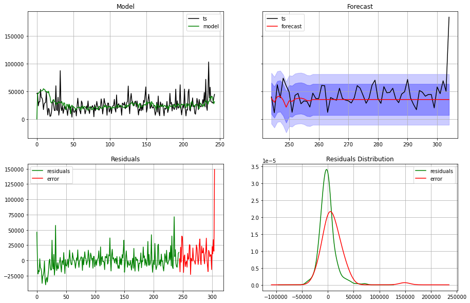

```
Training --> Residuals mean: -1079.0  | std: 14413.0
Test --> Error mean: 9861.0  | std: 23436.0  | mae: 15243.0  | mape: 35.0 %  | mse: 637476831.0  | rmse: 25248.0
```

```python
# building the model using the optimal 'order' and 'seasonal order' values we found above

dtf, model = fit_sarimax(train['Sales'], test['Sales'], order=(0,1,2),
                         seasonal_order=(0,0,2,7))
```

### Insights

We find that the MAPE of SARIMAX is 35% which means that our model is out with an average of 35% from the true value.

## Model Comparison

### FB Prophet model: MAPE = 26%

### SARIMAX model: MAPE = 35%

#### The lower the MAPE score, the better the model performance is. Hence, our FB Prophet model worked better than the SARIMAX model in this case.

### Conclusion

We used the sales data to create an FB Prophet timeseries model and SARIMAX model to forecast future sales and explore the hyperparameters we can tune to get the most out of the historic sales data. We found that our FB Prophet model works better than the SARIMAX model

In conclusion, by coupling our analysis with the insights from some domain knowledge experts, we would be able to make the best out of our data.

References: I referred various articles on customer segmentation from websites such as Medium, Analytics Vidhya, Stack Overflow and used the FB Prophet documentation for the time series forecasting.

I enjoyed working on this case study. Thank you very much for the opportunity!

### kishorkumarsridhar@gmail.com